# Measures of Central Tendency and Dispersion

Simon J. Kiss

17/03/2020

# Learning Outcomes

1. students should be able to demonstrate an understanding of:
   - mean
   - median
   - mode
   - variance
   - standard deviation
   - Normal distribution

# Goals of the presentation

2. Demonstrate concepts using the [Labour Force Survey](https://www.statcan.gc.ca/eng/survey/household/3701)
3. R code provided is meant to:
   - reinforce previous familiarity with R
   - demonstrate concepts

# Central Tendency

- One of the goals is to describe the world with numbers.
- describing where the centre of a set of data is is pretty useful

# Mean

- most common measure of central tendency

$\overline{x}=\frac{\sum_{i=1}^{N}x_{i}}{N}$

# Mean

## Example

Load data from the Labour Force Survey

- These data are stored in a file-format called `sav` which is really common in the social sciences
- loading the `haven` library provides the `read_sav()` command to read it in
- loading the `labelled` library lets us search through variables quickly

# Mean

## Example

```r
#install.packages(c('haven', 'labelled'))
library(haven)
lfs<-read_sav('https://github.com/sjkiss/DMJN328/raw/master/Lecture_Notes/mar_11/data/lfs.sav')
```

```r
library(labelled)
look_for(lfs, "wages")
```

```
##    variable                              label
## 36 HRLYEARN Usual hourly wages, employees only
```

# Mean

## Example

```r
look_for(lfs, "education")
```

```
##    variable                          label
## 11     EDUC Highest educational attainment
```

# Mean

## Example

```r
look_for(lfs, "sex")
```

```
##   variable             label
## 9      SEX Sex of respondent
```

# Mean

## Example

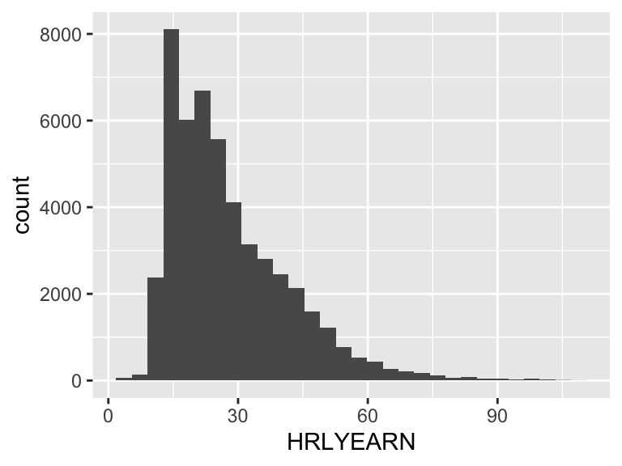

```r
library(tidyverse)
lfs %>%
  ggplot(., aes(x=HRLYEARN))+geom_histogram()
```

# Mean

## Calculate mean

```r
mean(lfs$HRLYEARN, na.rm=T)
```

```
## [1] 27.88198
```

# Mean

## Means by group

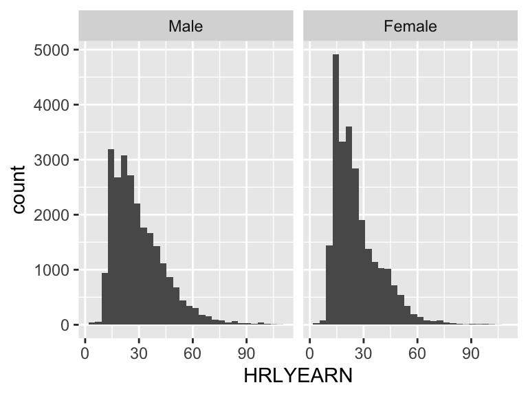

```r
lfs %>%
ggplot(., aes(x=HRLYEARN))+geom_histogram()+facet_wrap(~as_factor(SEX))
```

# Mean

## Means by group

```r
lfs %>%
group_by(SEX) %>%
summarize(avg=mean(HRLYEARN, na.rm=T))
```

```
## # A tibble: 2 x 2
##          SEX   avg
##    <dbl+lbl> <dbl>
## 1 1 [Male]    29.8
## 2 2 [Female]  26.0
```

# Median

- means are vulnerable to outliers

```r
vector1<-c(1,2,3,4,5,6,7,8,9,10)
mean(vector1)
```

```
## [1] 5.5
```

```r
vector2<-c(1,2,3,4,5,6,7,8,9,10, 1000000)
mean(vector2)
```

```
## [1] 90914.09
```

# Median

- Median is a different measure of central tendency
- The value at which half of a variable is above, half is below.

```r
lfs %>%
  group_by(SEX) %>%
  summarize(median=median(HRLYEARN, na.rm=T))
```

```
## # A tibble: 2 x 2
##          SEX median
##    <dbl+lbl>  <dbl>
## 1 1 [Male]     26.4
## 2 2 [Female]   22.3
```

# Median

- median is immune to outliers

```r
median(vector1)
```

```
## [1] 5.5
```

```r
median(vector2)
```

```
## [1] 6
```

# Mode

- Mode is the most frequently occurring variable in the data
- useful for categorical data

| Var1 | Freq |
| --- | --- |
| 0 to 8 years | 4841 |
| Some high school | 11951 |
| High school graduate | 20006 |
| Some postsecondary | 6207 |
| Postsecondary certificate or diploma | 33779 |
| Bachelor’s degree | 15166 |
| Above bachelor’s degree | 7225 |

# Mode

- Not usually measured for numeric data

# Measures of Dispersion

## Variance

- Often not just interested in the center of the data, but the distribution

```r
#make one class of fake data, average =75, standard deviation =1
class1<-rnorm(100, mean=75, sd=1)
#make a second class of fake data, average-=75, standard deviation = 10
class2<-rnorm(100, mean=75, sd=10)
#combine into a dataframe
df<-data.frame(class1, class2)
```

# Measures of Dispersion

## Variance

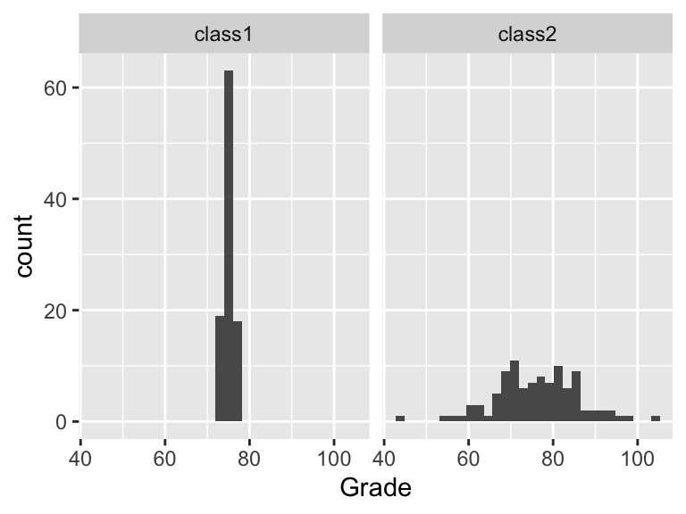

```r
df %>%
  #gather into Class and Grade
  gather(Class, Grade) %>%
  #Graph and facet
  ggplot(., aes(x=Grade))+geom_histogram()+facet_wrap(~Class)
```

# Measures of Dispersion

- different spreads have very different real-life consequences

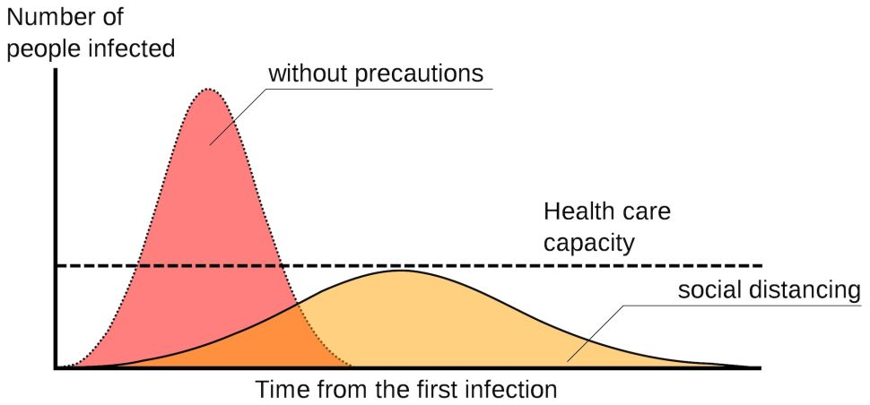

# Measures of Dispersion

## Variance

1. Subtract the average from each value
2. Square it to get rid of the negatives
3. Sum everything up
4. divide by the sample size.

# Measures of Dispersion

## Variance

$$s^2 = \textrm{sample variance}\\
\sum = \textrm{sum everything from the bottom to the top}\\
\overline{x} = \textrm{sample average}\\
N = \textrm{sample size}\\$$

$$s^2=\frac{\sum\limits_{i=1}^N{(x_i-\overline{x})}^2}{N-1}$$

# Variance

```r
#Step 1 is to subtract hte average from each value
step1<-lfs$HRLYEARN-mean(lfs$HRLYEARN, na.rm=T)
#step 2 is to square to get rid of the means
step2<-step1^2
#step 3 is to sum all of the variances, na.rm=T to remove missing values
step3<-sum(step2, na.rm=T)
#step 4 is to divide by the sample size (excluding missing values)
variance<-step3/(length(na.omit(lfs$HRLYEARN))-1)
#compare with the base
print(variance)
```

```
## [1] 194.1875
```

```r
var(lfs$HRLYEARN, na.rm=T)
```

```
## [1] 194.1875
```

# Standard Deviation

- variance is expressed in units squared
- unsquare it gives us a standard deviation

$$s=\sqrt{\frac{\sum\limits_{i=1}^N{(x_i-\overline{x})}^2}{N-1}}$$

- Commonly we talk about something being 1 standard deviation away, or two standard deviations away.
- Standard deviation is a number that describes the averge distance from the average in the units that variable is taken.

# Distributions

- Data come in different types (categorical, numeric)
- there are different processes in the universe that generate data
- data follow different distributions
  - Recall from ** The Joy of Stats** the importance of a distribution

# Distributions

1. Normal distribution
   - mean = median = mode
   - contstantly reoccurring pattern in nature

# Distributions

1. Normal distribution

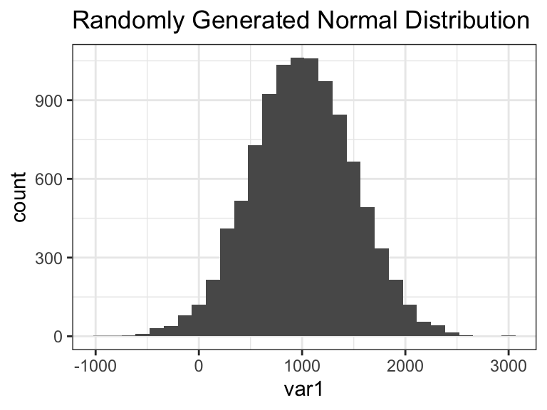

```r
#use rnorm to generate 10000 random numbers according to the normal distribution
#mean of 1000 and standard deviation of 500
var1<-rnorm(10000, mean=1000, sd=500)
#make into a data frame
df<-data.frame(var1)
#graph a histogram
ggplot(df, aes(x=var1))+geom_histogram()+theme_bw()+labs(title="Randomly Generated Normal Distribution")
```

```r
### Go back upand play with the mean and sd.
```

# Distributions

2. Uniform Distribution
   - numbers on a die

# Distributions

2. Uniform Distribution

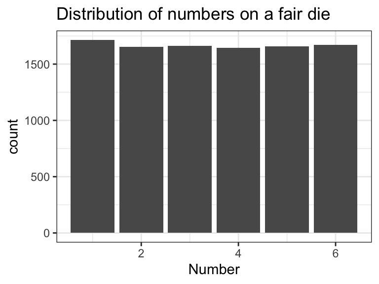

```r
#Sample a number from 1 to 6 (like on a die roll), 10000 times
var1<-sample(1:6, 10000, replace=T)
#turn into a dataframe (die)
die<-data.frame(var1)
#Graph as a
ggplot(die, aes(x=var1))+
  #as a barplot, counting the numbr of times each number occurs
  geom_bar(stat="count")+
  #turn it black and white
  theme_bw()+
  #give some labels
  labs(title="Distribution of numbers on a fair die", x="Number")
```

# Distributions

Normal Distribution

```r
mean(df$var1, na.rm=T)
```

```
## [1] 1001.175
```

```r
median(df$var1, na.rm=T)
```

```
## [1] 997.6412
```

# Normal Distribution

# Normal Distribution

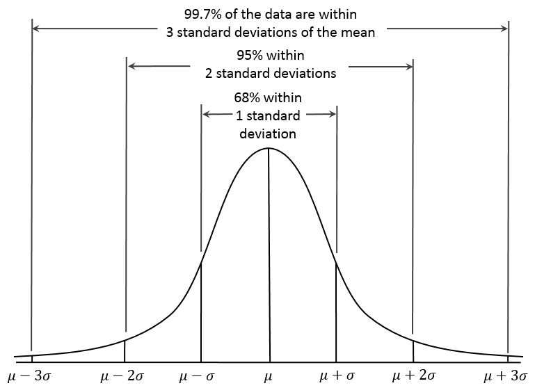